# Workflow of eQTL identification

Fu Xing[^1]

# Datasets and Preprocessing

> The SNP datasets for different Arabidopsis accessions were downloaded from the [1001 Genomes project website](http://1001genomes.org/data/GMI-MPI/releases/v3.1/).

```bash
# download the accession number list
mkdir vcf
wget http://1001genomes.org/data/GMI-MPI/releases/v3.1/intersection_snp_short_indel_vcf/ -P vcf
grep 'vcf.gz' vcf/index.html|sed -r 's/.+"intersection_//'|sed -r 's/\.vcf.+//'|sort -n > vcf/vcf_accession_list
```

> Gene expression data for different accessions were downloaded from [GEO:GSE80744](https://www.ncbi.nlm.nih.gov/geo/query/acc.cgi?acc=GSE80744). The expression levels are based on RNA-seq and were quantile normalized by Kawakatsu et al., and then the normalized expression levels were transformed with base 2 log.

```bash
# download the normalized expression data from GEO
mkdir geo
wget ftp://ftp.ncbi.nlm.nih.gov/geo/series/GSE80nnn/GSE80744/suppl/GSE80744_ath1001_tx_norm_2016-04-21-UQ_gNorm_normCounts_k4.tsv.gz -P geo
zcat geo/GSE80744_ath1001_tx_norm_2016-04-21-UQ_gNorm_normCounts_k4.tsv.gz > geo/GSE80744_ath1001_tx_norm_2016-04-21-UQ_gNorm_normCounts_k4.tsv

# find 665 accessions with both VCF and GEO data
cat geo/GSE80744_ath1001_tx_norm_2016-04-21-UQ_gNorm_normCounts_k4.tsv |head -1|sed 's/X//g'|sed -r 's/\t/\n/g'|grep -v 'gene' > geo/geo_accessions_list
cat vcf/vcf_accession_list geo/geo_accessions_list|sort -n|uniq -d > 665_accession
```

```r
# preprocess_gene_expression.R
geo <- read.table('geo/GSE80744_ath1001_tx_norm_2016-04-21-UQ_gNorm_normCounts_k4.tsv', header = T, row.names = 1)
colnames(geo) <- sub('X', '', colnames(geo))
acc <- read.table('665_accession')$V1

geo2 <- round(log2(geo[, colnames(geo) %in% c('gene_id', acc)] + 1), 2)
write.table(geo2, 'geo/gene_expression.tsv', quote=F, sep='\t', col.names = NA)

geo_pheno <- data.frame(FID=colnames(geo2),
                        IID=colnames(geo2),
                        t(geo2))
write.table(geo_pheno, 'geo/gene_expression_pheno.tsv', quote=F, sep='\t', row.names = FALSE)
```

> Select SNPs which locate in the genes with minor allele frequency threshold 0.01.

```bash
# extract SNPs (MAF>0.01) within genes in 665 accession from VCF file
wget -c http://1001genomes.org/data/GMI-MPI/releases/v3.1/1001genomes_snp-short-indel_only_ACGTN.vcf.gz -P vcf
bcftools index -t vcf/1001genomes_snp-short-indel_only_ACGTN.vcf.gz

# get total variant count of all accessions
bcftools index --nrecords vcf/1001genomes_snp-short-indel_only_ACGTN.vcf.gz
# get variant count per chromsome of all accessions
bcftools index --stats vcf/1001genomes_snp-short-indel_only_ACGTN.vcf.gz

vcftools --gzvcf vcf/1001genomes_snp-short-indel_only_ACGTN.vcf.gz --keep 665_accession --remove-indels --maf 0.01 --bed tair10_gene_28775.bed --recode --recode-INFO-all --stdout | bgzip -c > vcf/filtered_665_accession_snp_maf0.01_gene.vcf.gz

bcftools index -t vcf/filtered_665_accession_snp_maf0.01_gene.vcf.gz
# get total variant count
bcftools index --nrecords vcf/filtered_665_accession_snp_maf0.01_gene.vcf.gz
# get variant count per chromsome
bcftools index --stats vcf/filtered_665_accession_snp_maf0.01_gene.vcf.gz

## generate SNP matrix
vcftools --gzvcf vcf/filtered_665_accession_snp_maf0.01_gene.vcf.gz --012 --out vcf/filtered_665_accession_snp_maf0.01_gene_matrix
```

# POCRE and SKAT

```bash
# install PLINK
mkdir bin
wget -c http://s3.amazonaws.com/plink1-assets/plink_linux_x86_64_20191130.zip
unzip plink_linux_x86_64_20191130.zip -d bin

# install POCRE
wget -c http://www.stat.purdue.edu/~zhangdb/packages/POCRE/POCRE_0.1.0.tar.gz
R CMD INSTALL POCRE_0.1.0.tar.gz
```

> A dimension reduction method, POCRE, was used for an initial screening of genome-wide SNP markers. …… it efficiently selects a set of important candidates from genome-wide SNPs that captures maximum association with the transcript levels.

```r
## POCRE.R
## Note: run the fllowing code on node2 which has 2T RAM and 80 cores
library(POCRE)
library(data.table)
library(doParallel)
registerDoParallel(core=40)

rna <- read.table('geo/gene_expression.tsv', header = T, row.names = 1)
rna <- t(rna)

snp <- as.matrix(fread('vcf/filtered_665_accession_snp_maf0.01_gene_matrix.012'))
snp_pos <- read.table('vcf/filtered_665_accession_snp_maf0.01_gene_matrix.012.pos')

writeLines(c(""), "POCRE_log.txt")
st <- system.time({
  results <- foreach(i=1:ncol(rna)) %dopar% {
    cat(paste("Starting iteration", i, "\n"), file = 'POCRE_log.txt', append = TRUE)
    result <- pocrescreen(rna[, i, drop=F], snp)
    snp_pos[result$retSIdx, ]
  }
})

save(list = c('st', 'results'), file = 'RData/ROCRE.RData')
```

> The resulting markers were grouped based on gene annotations in TAIR10. SNPs in the same gene were grouped as one unit for association tests.

```r
## group_SNP.set.R
load('RData/ROCRE.RData')
snp <- unique(do.call(rbind, results))
bed <- data.frame(chr=snp$V1, start=snp$V2-1, end=snp$V2)
bed <- bed[order(bed$chr, bed$start), ]
write.table(bed, 'snp/SNP_candidates.bed', quote = F, sep = '\t', row.names = F, col.names = F)
```

```bash
## postprocess SNP candidates
bedtools intersect -a snp/SNP_candidates.bed -b tair10_gene_28775.bed -wa -wb|cut -f1-3,7|awk '{print $4"\t"$1":"$3}' > snp/SNP_candidates.SetID

bedtools intersect -header -a vcf/filtered_665_accession_snp_maf0.01_gene.vcf.gz -b snp/SNP_candidates.bed|awk -F '\t' 'BEGIN {OFS = FS} {if($3==".") $3=$1":"$2; print $0}' > snp/SNP_candidates.vcf

./bin/plink --vcf snp/SNP_candidates.vcf --make-bed --out plink/SNP_candidates
```

> The association tests were carried out using SKAT with transcript level of each gene as one phenotype (Ionita-Laza et al. 2013). SKAT is a flexible association test between a set of markers and a continuous or binary phenotype, allowing for natural and easy adjustment of covariates, such as population stratification correction.

```bash
## make phenotype .fam files
mkdir plink/fam
grep '^AT' geo/gene_expression.tsv|cut -f1|parallel --gnu "./bin/plink --vcf snp/SNP_candidates.vcf --pheno geo/gene_expression_pheno.tsv --pheno-name {} --make-just-fam --out plink/fam/{}"
rm plink/fam/*.log plink/fam/*.nosex
```

```r
## SKAT.R
## Note: run the fllowing code on node2 which has 2T RAM and 80 cores
library(SKAT)
library(doParallel)
registerDoParallel(core=40)

# Generate SSD file
File.Bed <- 'plink/SNP_candidates.bed'
File.Bim <- 'plink/SNP_candidates.bim'
File.Fam <- 'plink/SNP_candidates.fam'
File.SetID <- 'snp/SNP_candidates.SetID'
File.SSD <- 'plink/SNP_candidates.SSD'
File.Info <- 'plink/SNP_candidates.SSD.info'
Generate_SSD_SetID(File.Bed, File.Bim, File.Fam, File.SetID, File.SSD, File.Info)

fam_files <- dir('plink/fam/', full.names = T)
genes <- sub('.fam', '', dir('plink/fam'))

writeLines(c(""), "SKAT_log.txt")
st <- system.time({
  results <- foreach(i=1:length(fam_files), .verbose = F) %dopar% {
    cat(paste("Starting iteration", i, "\n"), file = 'SKAT_log.txt', append = TRUE)

    y <- Read_Plink_FAM(fam_files[i], Is.binary = FALSE)$Phenotype
    obj <- SKAT_Null_Model(y ~ 1, out_type = 'C')

    # open SSD and Info file and run SKAT
    SSD.INFO <- Open_SSD(File.SSD, File.Info)
    out <- SKAT.SSD.All(SSD.INFO, obj)
    Close_SSD()

    out$results$transcript <- genes[i]
    out$results
  }
})

save(list = c('st', 'results'), file = 'RData/SKAT.RData')
```

```r
## SKAT_postprocess.R
## Note: run the fllowing code on node2 which has 2T RAM and 80 cores
library(doParallel)
registerDoParallel(core=20)
load('RData/SKAT.RData')

pvalue <- unlist(sapply(results, function(x){x$P.value}))
pvalue_adj <- p.adjust(pvalue, method='BH')

## BH-adjusted p-value cutoff is set to 5e-5 (0.00005)
pvalue_cutoff <- max(pvalue[pvalue_adj < 5e-5])

writeLines(c(""), "SKAT_postprocess_log.txt")
st <- system.time({
  results_sig <- foreach(i=1:length(results)) %dopar% {
    cat(paste("Starting iteration", i, "\n"), file = 'SKAT_postprocess_log.txt', append = TRUE)
    x <- results[[i]]
    x <- x[x$P.value < pvalue_cutoff, c('SetID', 'transcript')]
    t(x)
  }
})

results_sig <- as.data.frame(t(do.call(cbind, results_sig)), stringsAsFactors=F)

save(list = c('results_sig'), file = 'RData/SKAT_sig.RData')
```

# Result

#### **Table 1. Summary of SKAT results**

```bash
bedtools window -a tair10_gene_28775.bed -b tair10_gene_28775.bed -w 20000|cut -f4,10 > tair10_gene_local_20kb
```

```r
load('RData/SKAT_sig.RData')
gene20kb <- read.table('tair10_gene_local_20kb')
geo <- read.table('geo/gene_expression.tsv', header = T, row.names = 1)
tmp <- merge(results_sig, gene20kb, by.x= 2, by.y = 1)
local_eqtl <- tmp[tmp$SetID == tmp$V2,]
total_gene <- c(Mitochondrion=length(grep('ATM', row.names(geo), value = T)),
                Chloroplast=length(grep('ATC', row.names(geo), value = T)),
                NuclearGenome=length(grep('AT[0-9]', row.names(geo), value = T)),
                Total=nrow(geo))
gene_with_eQTL <- c(Mitochondrion=length(table(grep('ATM', results_sig$transcript, value = T))),
                    Chloroplast=length(table(grep('ATC', results_sig$transcript, value = T))),
                    NuclearGenome=length(table(grep('AT[0-9]', results_sig$transcript, value = T))),
                    Total=length(unique(results_sig$transcript)))
gene_with_local_eQTL <- c(Mitochondrion=length(table(grep('ATM', local_eqtl$transcript, value = T))),
                          Chloroplast=length(table(grep('ATC', local_eqtl$transcript, value = T))),
                          NuclearGenome=length(table(grep('AT[0-9]', local_eqtl$transcript, value = T))),
                          Total=length(unique(local_eqtl$transcript)))
summary_table <- cbind(total_gene, gene_with_eQTL, gene_with_local_eQTL)
print(summary_table)
```

```
              total_gene gene_with_eQTL gene_with_local_eQTL
Mitochondrion         49             40                    0
Chloroplast           96             29                    0
NuclearGenome      24030          17413                 5391
Total              24175          17482                 5391
```

#### **Figure 1. Distribution of the numbers of eQTL identified for each transcript**

```r
## Figure1.R
y <- merge(as.data.frame(table(results_sig$transcript)),
           as.data.frame(table(local_eqtl$transcript)-1),
           by.x =1, by.y=1, all.x = T)
y[is.na(y)] <- 0
x <- y[,2] - y[,3]
x[x>200] <- 210

png('Figure1.png', wid=800, hei=400)
h <- hist(x, main='', ylab='Frequency', xlab='Number of eQTL Genes Identified by One Transcript')
text(h$mids[21], 2400, '>200')
dev.off()
```

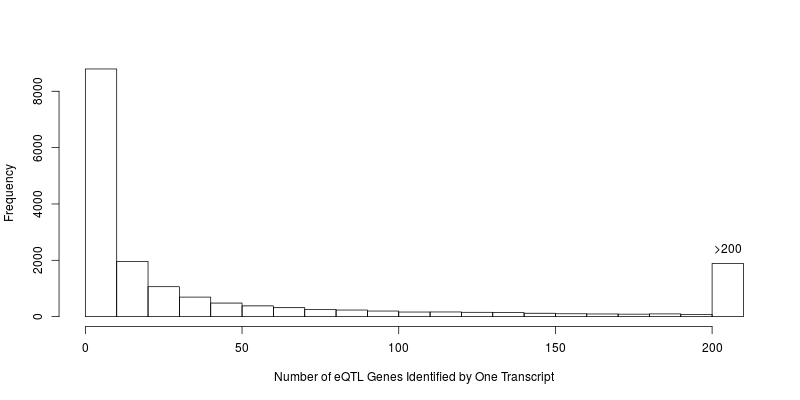

#### **Figure 2. Genomic distribution of eQTL**

```bash
bedtools makewindows -g tair10.chromSize -w 50000 |awk '{print $0"\t"NR}' > tair10_50kb_windows.bed
bedtools intersect -a tair10_gene_28775.bed -b tair10_50kb_windows.bed -wa -wb|cut -f4,10 > tair10_50kb_windows_genes
```

```r
## Figure2.R
gene_loc <- read.table('tair10_gene_28775.bed')

x1 <- merge(results_sig, gene_loc, by.x = 1, by.y = 4)[, 1:4]
colnames(x1)[3:4] <- c('SetID.chrom', 'SetID.start')

x2 <- merge(x1, gene_loc, by.x = 2, by.y = 4)[, 3:6]
colnames(x2)[3:4] <- c('transcript.chrom', 'transcript.start')

chrom_size <- c(30427671, 19698289, 23459830, 18585056, 26975502)
offset <- c(0, cumsum(chrom_size))

for (i in 1:5) {
  x2$SetID.start[x2$SetID.chrom == i] <- x2$SetID.start[x2$SetID.chrom == i] + offset[i]
  x2$transcript.start[x2$transcript.chrom == i] <- x2$transcript.start[x2$transcript.chrom == i] + offset[i]
}

png('Figure2A.png', wid=800, hei=800)
plot(x2$SetID.start, x2$transcript.start, pch=16, cex=0.01, col='blue', xlab='Genomic Location of eQTL Genes', ylab='Genomic Location of Phenotypic Genes', xaxt='n', yaxt='n', bty='n')
abline(h=offset, lwd=2)
abline(v=offset, lwd=2)
mtext(text=paste0('Chr', 1:5), side=1, at=offset[1:5]+diff(offset)/2)
mtext(text=paste0('Chr', 1:5), side=2, at=offset[1:5]+diff(offset)/2)
dev.off()
```

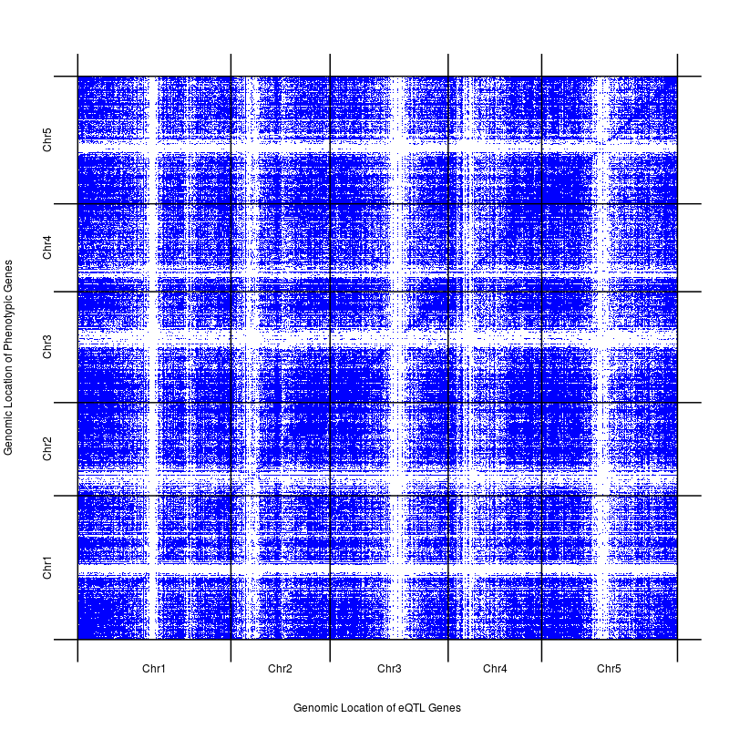

```r
window_50kb <- read.table('tair10_50kb_windows_genes', stringsAsFactors = F)
x3 <- merge(window_50kb, results_sig, by.x = 1, by.y = 1)
dfm <- as.data.frame(table(x3$V2))

win <- merge(data.frame(win=1:2385), dfm, by.x=1, by.y = 1, all.x = T)
win[is.na(win)] <- 0

png('Figure2B.png', wid=800, hei=400)
plot(win$win, win$Freq, type = 'l', xlab='Genomic Location', ylab='Number of Associated Transcripts', col='gray', xaxt='n', las=2)
abline(h=quantile(win$Freq, 0.99), col='red')
window_50kb$chrom <- sub('G.+', 'G', window_50kb$V1)
y <- sapply(split(window_50kb$V2, window_50kb$chrom), function(x){rev(x)[1]})
abline(v=c(0,y))
mtext(text=paste0('Chr', 1:5), side=1, at=diff(c(0,y))/2 + c(0, y[1:4]), line = 1)
dev.off()
```

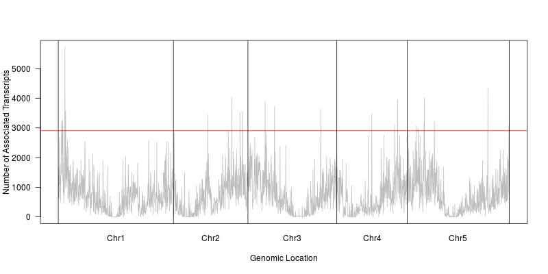

#### **Figure 3. Gene ontology enrichment of putative hotspot eQTL genes**

```r
library(topGO)
library(GO.db)

topGO <- function(myGenes, category='BP', p_cutoff=0.05, gomap, geneid){
  geneID2GO <- readMappings(file = gomap)
  geneNames <- read.table(geneid, stringsAsFactors=F)$V1
  geneList <- factor(as.integer(geneNames %in% myGenes))
  names(geneList) <- geneNames
  GOdata <- new("topGOdata", ontology=category, allGenes=geneList, annot=annFUN.gene2GO, gene2GO=geneID2GO)
  resultFisher <- runTest(GOdata, algorithm = "weight", statistic = "fisher")
  allRes <- GenTable(GOdata,pvalue=resultFisher,topNodes=100)
  allRes$pvalue[grep('<',allRes$pvalue)] <- "1e-30"
  allRes$pvalue <- as.numeric(allRes$pvalue)
  allRes <- allRes[order(allRes$pvalue,decreasing=F),]
  allRes$catagory <- category
  allRes <- allRes[allRes$pvalue < p_cutoff, ]
  allRes$Term <- apply(allRes, 1, function(x){Term(GOTERM[[x[1]]])})
  return(allRes)
}

top1k <- names(sort(-table(results_sig$SetID))[1:1000])

go <- topGO(top1k, gomap='tair10_gene2go.map', geneid='tair10_gene2go.geneid')
```

```r
go[, c('Term', 'pvalue')]
```

```
                                                                              Term  pvalue
1                                                               response to insect 0.00054
2                                                   carbohydrate catabolic process 0.00077
3                                                     regulation of leaf formation 0.00124
4                                                 endomembrane system organization 0.00135
5                                           ER to Golgi vesicle-mediated transport 0.00166
6                                           vesicle docking involved in exocytosis 0.00227
7                                                          gametophyte development 0.00261
8                          vegetative to reproductive phase transition of meristem 0.00272
9                                                         starch metabolic process 0.00332
10 positive regulation of transcription elongation from RNA polymerase II promoter 0.00363
11                                                         plant ovule development 0.00367
12                                                            polar nucleus fusion 0.00472
13                                    nicotinamide nucleotide biosynthetic process 0.00517
14                                                    tryptophan metabolic process 0.00565
```

[output cut: 66 more lines]

#### **Figure 4. Nuclear eQTL gene hotspots for mitochondrial and chloroplastic transcripts.**

```r
## Figure4.R
mito <- x2[grep('MG', x2$transcript), ]
x4 <- merge(as.data.frame(table(mito$SetID)), gene_loc, by.x = 1, by.y = 4)[, 1:4]
for (i in 1:5) {
  x4$V2[x4$V1 == i] <- x4$V2[x4$V1 == i] + offset[i]
}

png('Figure4A.png', wid=800, hei=400)
plot(x4$V2, x4$Freq, xlim=range(offset), xlab='', ylab='Number of Transcripts', xaxt='n', main=paste0('Mitochondrial Gene (n = ',length(unique(mito$transcript)),')'))
abline(v=offset, lwd=2)
mtext(text=paste0('Chr', 1:5), side=1, at=offset[1:5]+diff(offset)/2, line = 1)
dev.off()
```

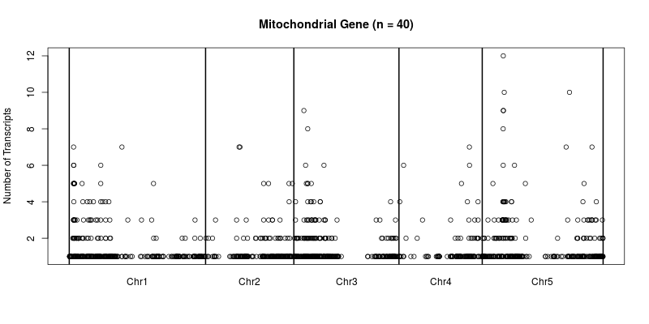

```r
chlo <- x2[grep('CG', x2$transcript), ]
x5 <- merge(as.data.frame(table(chlo$SetID)), gene_loc, by.x = 1, by.y = 4)[, 1:4]
for (i in 1:5) {
  x5$V2[x5$V1 == i] <- x5$V2[x5$V1 == i] + offset[i]
}

png('Figure4B.png', wid=800, hei=400)
plot(x5$V2, x5$Freq, xlim=range(offset), xlab='', ylab='Number of Transcripts', xaxt='n', main=paste0('Chloroplastic Gene (n = ',length(unique(chlo$transcript)),')'))
abline(v=offset, lwd=2)
mtext(text=paste0('Chr', 1:5), side=1, at=offset[1:5]+diff(offset)/2, line = 1)
dev.off()
```

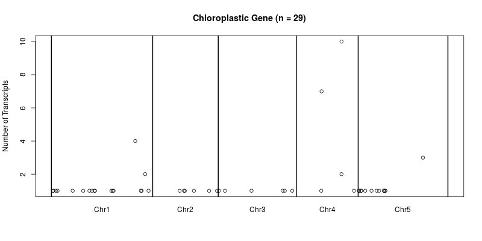

# Reference

Wang et al. Large-scale eQTL identification in Arabidopsis reveals novel candidate regulators of immune responses and other processes.

[^1]: bio.xfu@qq.com